# Redwine Analysis

# Multivariate Plots Section

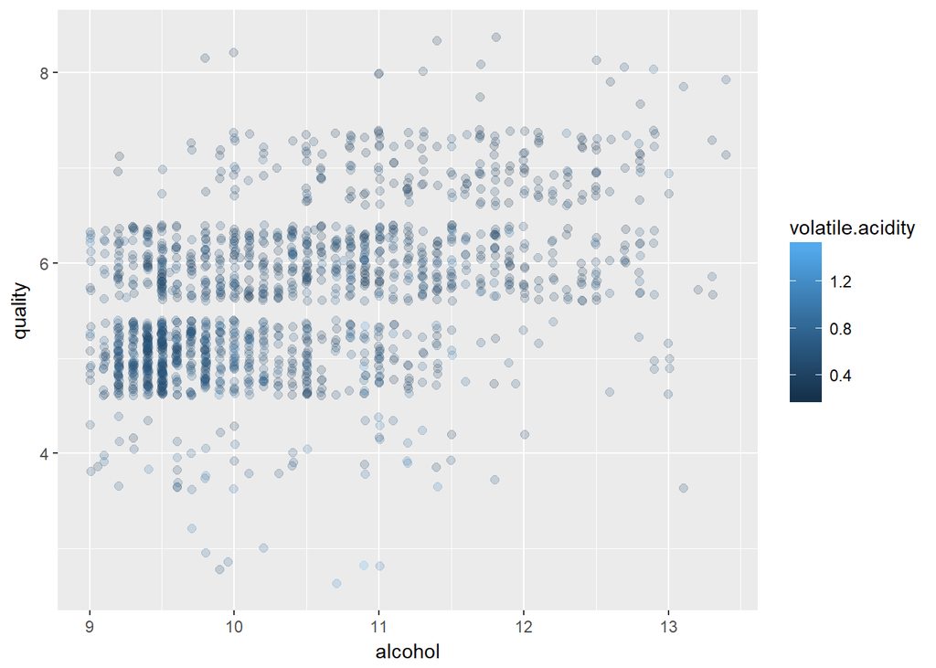

The plot shows there is a week relationship between alcohol and volatile acidity.

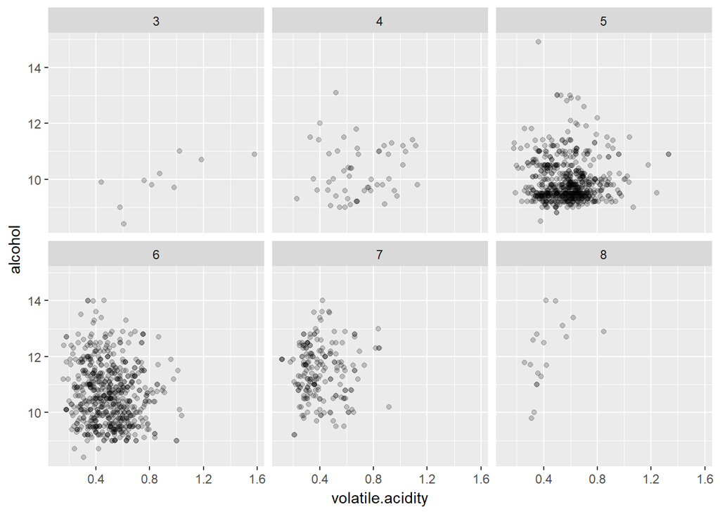

This plot shows wine with quality index 8 has higher alcohol and low volatile acidity.

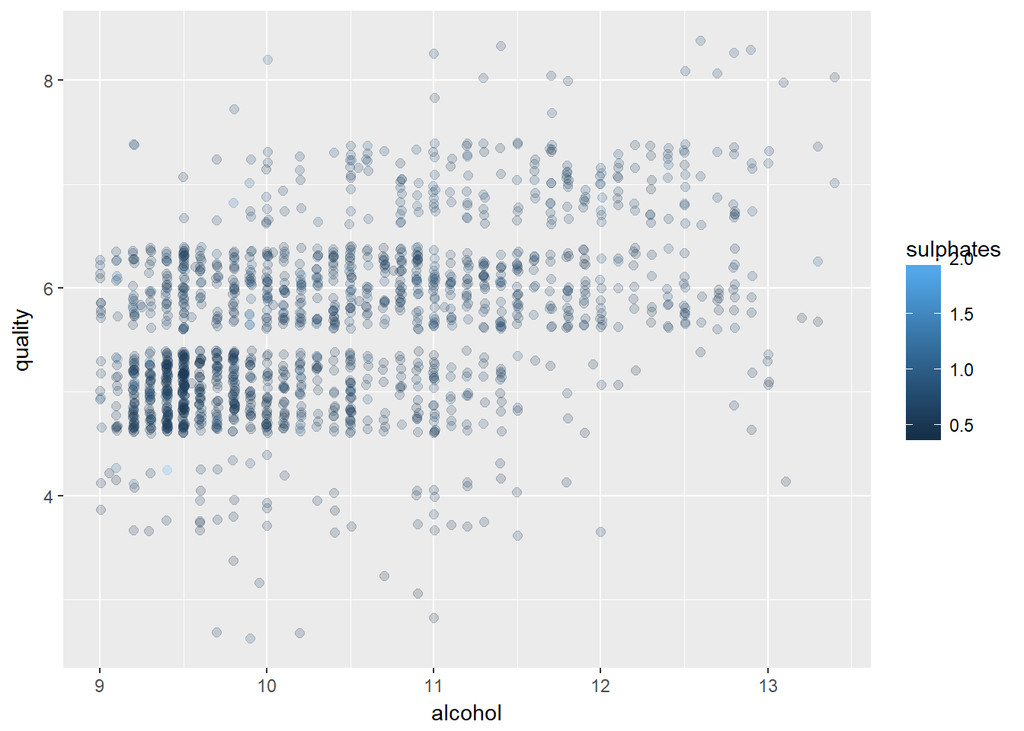

It appears that high wine quality have high sulphates.

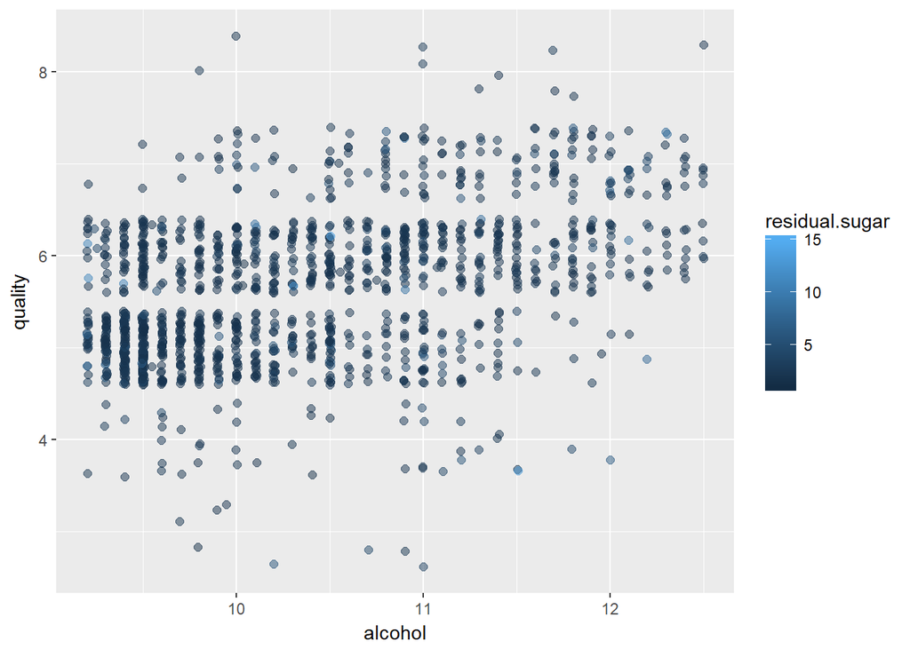

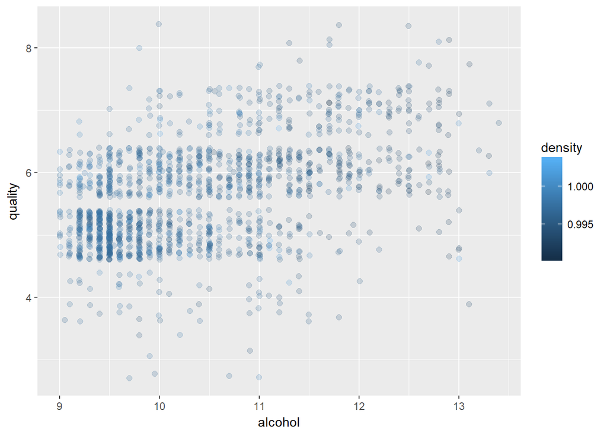

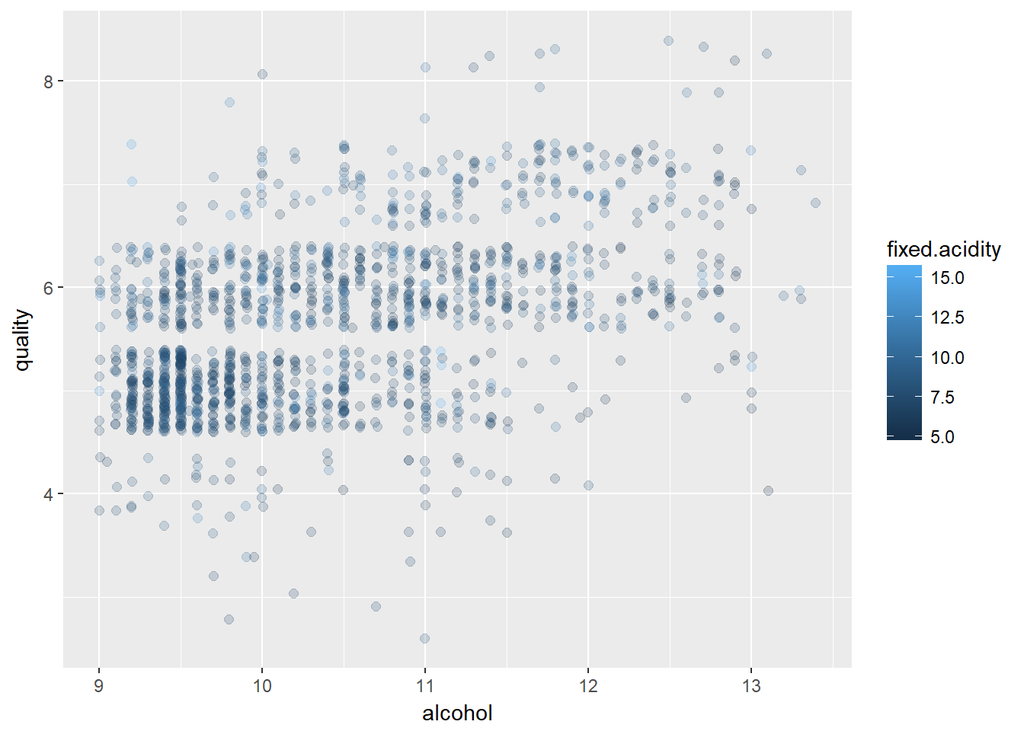

The above charts were not able to reveal any significant relationships among the variables.

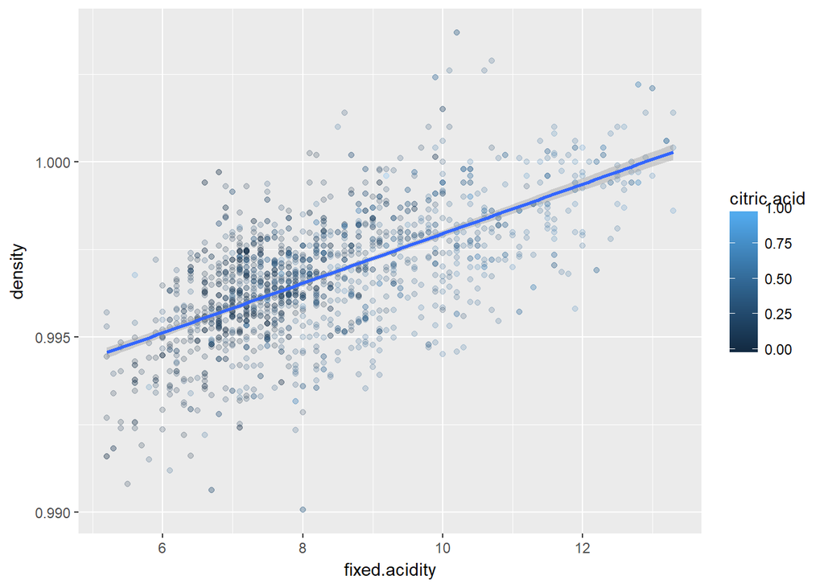

This chart is more interesting as it shows (i) there is a positive correlation between fixed acidity and density. and (ii) for a given level of fixed acidity, the higher level of citric acid, the lower the density.

Now I want to quantify the relationship of various input variables with quality. I will convert to convert the factor quality into a numerical variable and run a linear regession model. The assumption that the final quality score is rounded to the nearest interger number.

```
##
## Calls:
## m1: lm(formula = quality ~ alcohol, data = redwine)
## m2: lm(formula = quality ~ alcohol + volatile.acidity, data = redwine)
## m3: lm(formula = quality ~ alcohol + volatile.acidity + sulphates,
##     data = redwine)
## m4: lm(formula = quality ~ alcohol + volatile.acidity + sulphates +
##     citric.acid, data = redwine)
##
## ============================================================================
##                          m1            m2            m3            m4
## ----------------------------------------------------------------------------
##   (Intercept)           1.875***      3.095***      2.611***      2.646***
##                        (0.175)       (0.184)       (0.196)       (0.201)
##   alcohol               0.361***      0.314***      0.309***      0.309***
##                        (0.017)       (0.016)       (0.016)       (0.016)
##   volatile.acidity                   -1.384***     -1.221***     -1.265***
##                                      (0.095)       (0.097)       (0.113)
##   sulphates                                         0.679***      0.696***
##                                                    (0.101)       (0.103)
##   citric.acid                                                    -0.079
##                                                                  (0.104)
## ----------------------------------------------------------------------------
##   R-squared             0.227         0.317         0.336         0.336
##   adj. R-squared        0.226         0.316         0.335         0.334
##   sigma                 0.710         0.668         0.659         0.659
##   F                   468.267       370.379       268.912       201.777
##   p                     0.000         0.000         0.000         0.000
##   Log-likelihood    -1721.057     -1621.814     -1599.384     -1599.093
##   Deviance            805.870       711.796       692.105       691.852
##   AIC                3448.114      3251.628      3208.768      3210.186
##   BIC                3464.245      3273.136      3235.654      3242.448
##   N                  1599          1599          1599          1599
## ============================================================================
```

The model confirms that the most important variables (alcohol, volatile acidity sulphates, and citric acid) can only explain 33.6% of quality. There is no additional improvement as the last variable citric acid did not improve  
R-square.

# Multivariate Analysis

### Talk about some of the relationships you observed in this part of the investigation. Were there features that strengthened each other in terms of looking at your feature(s) of interest?

As suspected, due to the week correlation among variables, our multivariate analysis only gain modest additional insights.

### Were there any interesting or surprising interactions between features?

While quality does not have strong correlation with other variables, fixed acidity has fairly strong correlation with density, pH, and citric acid.

### OPTIONAL: Did you create any models with your dataset? Discuss the strengths and limitations of your model.

As commented previously, it seems quality is impacted by various factors, and some of those might not be included in the data set. Therefore, I created a linear regression model to access how much the top 4 physicochemical propereties explain the wine quality. The model is only able to explain one third of the variation in quality. ——

# Final Plots and Summary

### Plot One

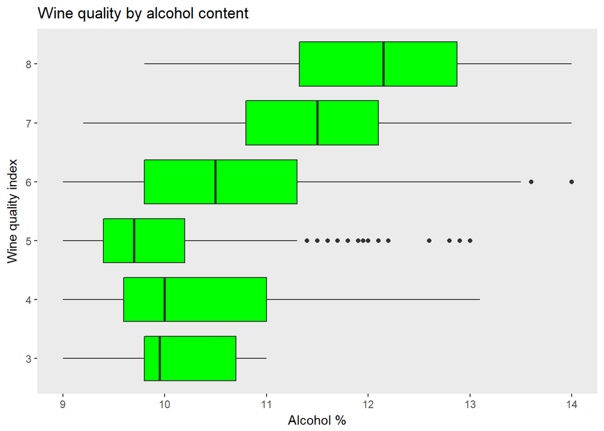

### Description One

It is surprising to see there is a relationship between wine quality and its alcohol content. Median alcohol content of higer quality wine (7 and 8) is higher than 11%, while most lower wine quality have alcohol below 11%.

### Plot Two

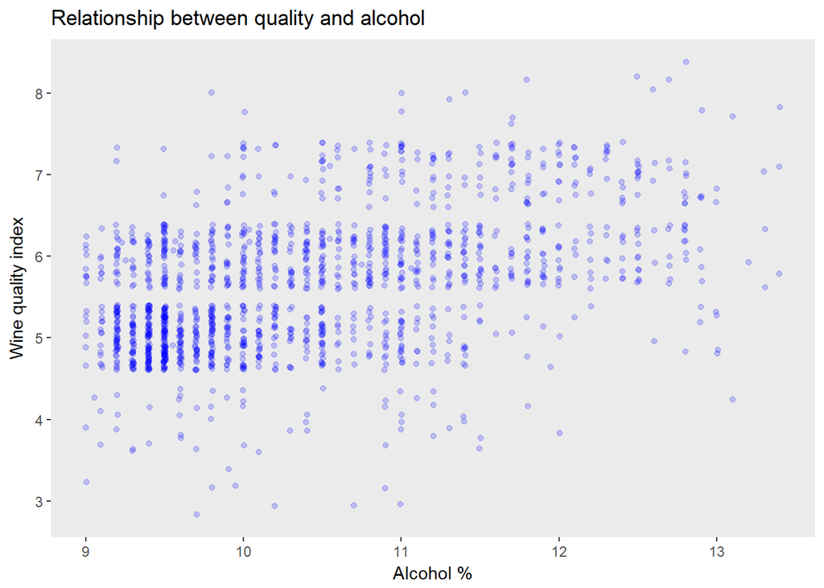

### Description Two

Among the variables, alcohol content has highest correlation to wine quality. However, the plot indicated that the relationship is weak. The top 4 variables (alcohol, variable acidity, sulphates, and citric acid) can only explain one-third of the quality of redwine. THis indicates that there are many other factors that influence the wine quality that is missing from the dataset (for example, grape types or regions)

### Plot Three

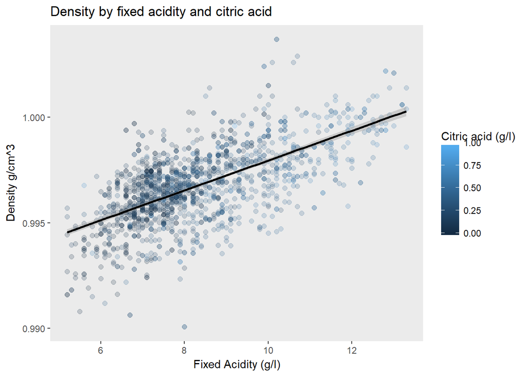

### Description Three

There is a strong positive correlation between fixed acidity and density and for a given level of fixed acidity, the higher level of citric acid, the lower the density.

# Reflection

The wine datasetcontains information on 1600 samples with 12 variable. I started by understanding the individual variables in the data set, and then I created many plots to understand the relationship among variables, most important to find out the important variables that might influence quality.

It is interesting to understand the values and distributions of the variables. The frustration startedafter I built the scatterplot matrix that shows weak correlations between quality and other variables. The multivariate analysis further confirm the hypothesis that there are might be so many factors influence wine quality, or the important factors (grape types, wine region) were not captured in the dataset. It is interesting to understant the relationship between alcohol level with with quality, as well as volatile acidity with quality. Also, it is suprising to discover that there is a high correlation among fixed acidity, citric acid, and density.

For future work related to this dataset, I would like to include additional variables that could be important in determining the quality of the wine. From my experience, the wine quality could depend on the grape variety (for example, merlot,cabernet sauvignon, shiraz, etc.), the wine region, and the year of the wine. Adding these additional variable can help us to build a better predictive model of wine quality.